# JSC370: Assignment 1

Exploring daily temperature change in Fort Ross, Nunavut overtime

Shih-Ting (Cindy) Huang

2/3/2022

## 1. Importing and Checking the Data

After importing the two datasets on daily temperature in Fort Ross, Nunavut during 1939 and 2021, we proceed to check for import issues.

```
##              Data Quality             Max Temp Flag            Min Temp (Â°C)
##               1.000000000               1.000000000               0.005479452
##           Mean Temp (Â°C)       Heat Deg Days (Â°C)       Cool Deg Days (Â°C)
##               0.005479452               0.005479452               0.005479452
##           Total Rain (mm)           Total Rain Flag           Total Snow (cm)
##               0.169863014               1.000000000               0.169863014
##         Total Precip (mm)         Snow on Grnd (cm)         Snow on Grnd Flag
##               0.169863014               1.000000000               1.000000000
## Dir of Max Gust (10s deg)      Dir of Max Gust Flag    Spd of Max Gust (km/h)
##               1.000000000               1.000000000               1.000000000
##      Spd of Max Gust Flag
##               1.000000000
```

and the 2021 dataset:

```
##              Data Quality            Max Temp (Â°C)            Min Temp (Â°C)
##                 1.0000000                 0.1232877                 0.1287671
##           Mean Temp (Â°C)       Heat Deg Days (Â°C)       Cool Deg Days (Â°C)
##                 0.1287671                 0.1287671                 0.1287671
##           Total Rain (mm)           Total Rain Flag           Total Snow (cm)
##                 1.0000000                 1.0000000                 1.0000000
##           Total Snow Flag         Total Precip (mm)         Snow on Grnd (cm)
##                 1.0000000                 0.4739726                 0.3753425
##         Snow on Grnd Flag Dir of Max Gust (10s deg)    Spd of Max Gust (km/h)
##                 1.0000000                 0.7698630                 0.7698630
```

In order to merge the two years’ data, we will not include variables with 100% NA values in our investigation as they do not add any information. We won’t remove any rows with NA values but will exclude them when calculating summary statistics like mean, median, etc.

## 2. Data Cleaning

First, we exclude the following variables because they have 100% NA values in one of the two datasets:

- “Data Quality”, “Max Temp Flag”, “Total Rain Flag”, “Snow on Grnd (cm)”, “Snow on Grnd Flag”, “Dir of Max Gust (10s deg)”, “Dir of Max Gust Flag”, “Spd of Max Gust (km/h)”, “Spd of Max Gust Flag”, “Total Rain (mm)”, “Total Snow (cm)”, “Total Snow Flag”

We also rename columns with special characters, such as “Mean Temp (Â°C)”, to more easily access and refer to those variables.

Checking that both datasets are cleaned, we merge them with full join to preserve all the NA values for individual observations. In the merged dataset, we have 730 observations and 19 columns.

## 3. Exploratory Data Analysis

To investigate whether daily temperature in Fort Ross, Nunavut has significantly changed from 1939 to 2021, we first look at some statistics for each year, specifically those related to temperature.

This summarizes some key values for 1939:

```
##   Max Temp Mean Max Temp Median Max Temp Variance Min Temp Mean Min Temp Median
## 1     -11.87096           -12.2          196.8342     -18.30634             -20
##   Min Temp Variance Avg Temp Mean Avg Temp Median Avg Temp Variance
## 1          207.9871     -15.14518           -15.9          200.3019
```

This summarizes some key values for 2021:

```
##   Max Temp Mean Max Temp Median Max Temp Variance Min Temp Mean Min Temp Median
## 1      -8.32125            -6.7          154.5454     -14.50597           -14.8
##   Min Temp Variance Avg Temp Mean Avg Temp Median Avg Temp Variance
## 1          176.6049     -11.44182          -11.25           163.308
```

Comparing the two years’ statistics on temperature, we see that the mean and median for maximum, minimum, and average temperature have increased from 1939 to 2021 with less variance in all three variables. Using this insight, we then want to formally test if there’s a relationship between year and these temperature measurements.

First, we consider linear regression, for which we have to verify assumptions such as population normality. Daily mean temperature was chosen for studying if there’s temperature change overtime.

```
##
## Call:
## lm(formula = mean_temp ~ Year, data = merged, na.action = na.omit)
##
## Residuals:
##      Min       1Q   Median       3Q      Max
## -29.6582 -10.7548  -0.2582  12.9418  22.9452
##
## Coefficients:
##               Estimate Std. Error t value Pr(>|t|)
## (Intercept) -102.71598   25.06215  -4.098 4.66e-05 ***
## Year           0.04516    0.01267   3.564 0.000391 ***
## ---
## Signif. codes:  0 '***' 0.001 '**' 0.01 '*' 0.05 '.' 0.1 ' ' 1
##
## Residual standard error: 13.53 on 679 degrees of freedom
##   (49 observations deleted due to missingness)
## Multiple R-squared:  0.01836,    Adjusted R-squared:  0.01692
## F-statistic:  12.7 on 1 and 679 DF,  p-value: 0.000391
```

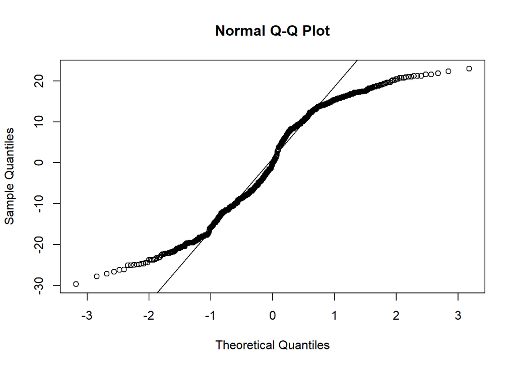

For this test, our null hypothesis is that daily mean temperature does not differ between 1939 and 2021 at the weather station.

```r
wilcox.test(mean_temp~Year, data = merged)
```

```
##
##  Wilcoxon rank sum test with continuity correction
##
## data:  mean_temp by Year
## W = 48700, p-value = 0.0004311
## alternative hypothesis: true location shift is not equal to 0
```

With a p-value of 0.00043, we have strong evidence against the null hypothesis, suggesting that daily mean temperature is very possibly different across the two years. Combined with the earlier summary statistics, it would imply daily mean temperature has increased from 1939 to 2021.

## 4. Supporting Visuals

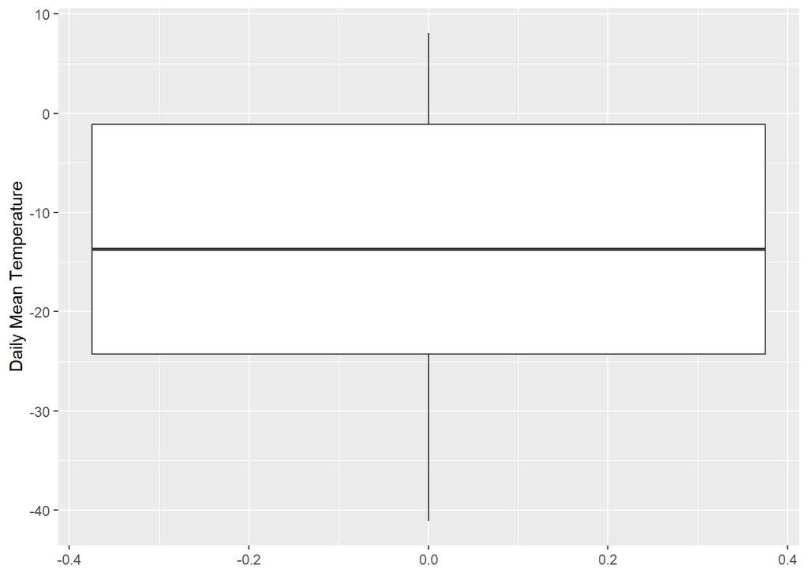

Boxplot for daily mean temperature at Fort Ross, Nunaavut weather station.

Here, we take note that there aren’t outliers identified by the boxplot, which is good because it means they didn’t affect the validity of our statistical conclusions.

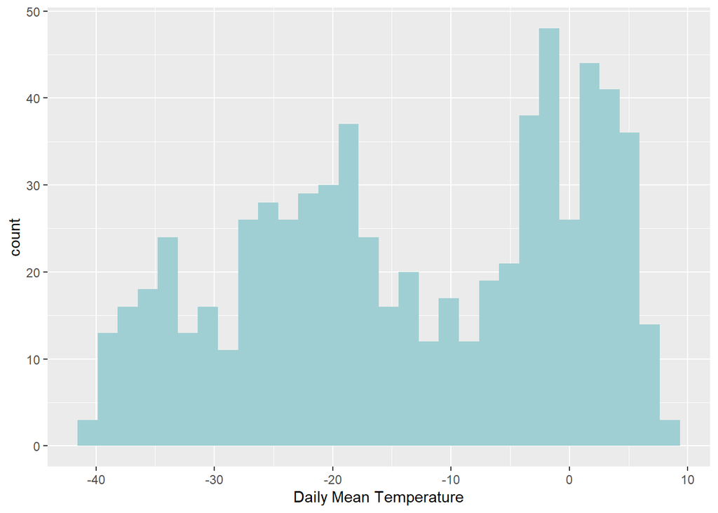

Histogram for daily mean temperature at Fort Ross, Nunavut weather station.

From the histogram, we can see that daily mean temperature isn’t normally distributed, with peaks in several temperature ranges.

Using leaflet, we create a map to illustrate where the weather station is located during each year recorded in the merged dataset.

```r
# Define a color for each year
yearCol <- colorFactor(palette = c("#FF6542", "#E8CEE4"), merged$Year)

# Create a map
merged %>%
  leaflet() %>%
  addProviderTiles('OpenStreetMap') %>%
  addCircles(lat=~`Latitude (y)`, lng=~`Longitude (x)`, opacity=1, fillOpacity=1, radius=100, color=~yearCol(Year)) %>%
  addLegend('bottomright', pal = yearCol, values = merged$Year,
            title = 'Weather Station Location in Year',
            opacity = 1)
```

[interactive chart not shown]

In the map above, we observe that the weather station moved further north from 1939 to 2021. Usually with a further northern location, daily temperature is more likely to decrease. However in the case of this dataset, the opposite occurred, suggesting that other factors increasing temperature overtime outweighed the effect of change in location.